# Plotting Single Season Occupancy Modeling Results in R Using ggplot

### First load required packages

**If you need to install the packages, you can do so directly in R Studio (Tools –> Install Packages or Packages –> Install), or you can use commands like these in your R Script: install.packages(“unmarked”). Once downloaded, you’ll need to call the packages you want to use in R using library(packagename) or require(packagename). When you call a package, R automatically calls other packages that are needed.**

```r
library(unmarked) # need this for fitting an occupancy model
```

```r
library(ggplot2) # need this for making plots
library(dplyr) # need this for data manipulation
library(tidyr) # need this for data manipulation
```

### Now import a data set

**We’ll use the *Medionidus walkeri* data for this example.**

```r
options(scipen=999) # suppress printing scientific notation
walkeri<-read.csv("SingleSeasonOccupancy_Mwalkeri.csv")
```

### Now subset the data frame

**Here, we’re separating the observation data, observation-level covariates, and site-level covariates.**

```r
###############################
### Medionidus walkeri data ###
###############################
head(walkeri) # take a look at the first few rows of the data
```

```
##   Site nMagnitude1 nMagnitude2 nMagnitude3 nMagnitude4 nSprings SpringQcfs SpringQcms stSpringQcms
## 1    1           5           1           1           1        8      511.1  14.472741   -0.1477218
## 2    2           4           1           1           1        7      411.1  11.641056   -0.2730725
## 3    3           0           0           0           0        0        0.0   0.000000   -0.7883893
## 4    4           8          20           8           2       38     1008.2  28.549045    0.4753966
## 5    5           1          10           2           0       13      202.0   5.720003   -0.5351809
## 6    6           5          22          12          11       50      733.1  20.759081    0.1305568
##   Latitude Longitude              Stream SurveyDate TotalEffort nOccasions Total_MW Occ1 Occ2 Occ3
## 1 29.85437 -82.61341      Santa Fe River 10/22/2013         2.5          3        0    0    0    0
## 2 29.85392 -82.61288      Santa Fe River 10/22/2013         2.0          3        0    0    0    0
## 3 29.92623 -82.41117           New River 10/24/2013         2.0          3        0    0    0    0
## 4 29.86478 -82.73958           New River 10/30/2013         3.0          2        0    0    0   NA
## 5 30.39175 -83.17715 Withlacoochee River  7/15/2014         2.0          3        0    0    0    0
## 6 30.36815 -83.19300      Suwannee River  7/24/2014         1.0          3        0    0    0    0
##   Occ4 Occ5 Occ6 Occ7 Occ8   Effort1   Effort2   Effort3   Effort4   Effort5   Effort6   Effort7
## 1   NA   NA   NA   NA   NA 0.8333333 0.8333333 0.8333333 0.8333333 0.8333333 0.8333333 0.8333333
## 2   NA   NA   NA   NA   NA 0.6666667 0.6666667 0.6666667 0.6666667 0.6666667 0.6666667 0.6666667
## 3   NA   NA   NA   NA   NA 0.6666667 0.6666667 0.6666667 0.6666667 0.6666667 0.6666667 0.6666667
## 4   NA   NA   NA   NA   NA 1.5000000 1.5000000 1.5000000 1.5000000 1.5000000 1.5000000 1.5000000
## 5   NA   NA   NA   NA   NA 0.6666667 0.6666667 0.6666667 0.6666667 0.6666667 0.6666667 0.6666667
## 6   NA   NA   NA   NA   NA 0.3333333 0.3333333 0.3333333 0.3333333 0.3333333 0.3333333 0.3333333
##     Effort8 stEffort1 stEffort2 stEffort3 stEffort4 stEffort5 stEffort6 stEffort7 stEffort8
## 1 0.8333333  2.637017  2.637017  2.637017  2.637017  2.637017  2.637017  2.637017  2.637017
## 2 0.6666667  1.661970  1.661970  1.661970  1.661970  1.661970  1.661970  1.661970  1.661970
## 3 0.6666667  1.661970  1.661970  1.661970  1.661970  1.661970  1.661970  1.661970  1.661970
## 4 1.5000000  6.537206  6.537206  6.537206  6.537206  6.537206  6.537206  6.537206  6.537206
## 5 0.6666667  1.661970  1.661970  1.661970  1.661970  1.661970  1.661970  1.661970  1.661970
## 6 0.3333333 -0.288125 -0.288125 -0.288125 -0.288125 -0.288125 -0.288125 -0.288125 -0.288125
```

```r
walkeriObs<-walkeri[,17:24] # subset columns for observation data
walkeriObsCovs<-walkeri[,c(1,25:40)] # subset columns for observation-level covariates
walkeriSiteCovs<-walkeri[,1:16] # subset columns for site-level covariates
```

### We need to re-format the observation-level covariates for unmarked.

**There are many ways to do this, but we’ll use reshape2 to melt the data (convert Effort and stEffort from wide to long format), reorder, and then combine them.**

```r
Effort<-walkeriObsCovs[,1:9]
stEffort<-walkeriObsCovs[,c(1,10:17)]
Effort2 <- melt(Effort, id.vars = "Site")
Effort2 <- Effort2[with(Effort2, order(Site, variable)),]
stEffort2 <- melt(stEffort, id.vars = "Site")
stEffort2 <- stEffort2[with(stEffort2, order(Site, variable)),]
EffortFin2 <- data.frame(Site = Effort2[,1], Effort = Effort2[,3], stEffort = stEffort2[,3])
print(EffortFin2[1:24,])
```

```
##    Site    Effort stEffort
## 1     1 0.8333333 2.637017
## 2     1 0.8333333 2.637017
## 3     1 0.8333333 2.637017
## 4     1 0.8333333 2.637017
## 5     1 0.8333333 2.637017
## 6     1 0.8333333 2.637017
## 7     1 0.8333333 2.637017
## 8     1 0.8333333 2.637017
## 9     2 0.6666667 1.661970
## 10    2 0.6666667 1.661970
## 11    2 0.6666667 1.661970
## 12    2 0.6666667 1.661970
## 13    2 0.6666667 1.661970
## 14    2 0.6666667 1.661970
## 15    2 0.6666667 1.661970
## 16    2 0.6666667 1.661970
## 17    3 0.6666667 1.661970
## 18    3 0.6666667 1.661970
## 19    3 0.6666667 1.661970
## 20    3 0.6666667 1.661970
## 21    3 0.6666667 1.661970
## 22    3 0.6666667 1.661970
## 23    3 0.6666667 1.661970
## 24    3 0.6666667 1.661970
```

### Just FYI, we can do the same thing using dplyr and tidyr’s gather (melt) and arrange (order) functions.

```r
Effort3 <- Effort %>% gather(variable, value, -Site) %>% arrange(Site, variable)
stEffort3 <- stEffort %>% gather(variable, value, -Site) %>% arrange(Site, variable)
EffortFin3 <- data.frame(Site = Effort3$Site, Occasion = Effort3$variable, Effort = Effort3$value, stEffort = stEffort3$value)
print(EffortFin3[1:24,])
```

```
##    Site Occasion    Effort stEffort
## 1     1  Effort1 0.8333333 2.637017
## 2     1  Effort2 0.8333333 2.637017
## 3     1  Effort3 0.8333333 2.637017
## 4     1  Effort4 0.8333333 2.637017
## 5     1  Effort5 0.8333333 2.637017
## 6     1  Effort6 0.8333333 2.637017
## 7     1  Effort7 0.8333333 2.637017
## 8     1  Effort8 0.8333333 2.637017
## 9     2  Effort1 0.6666667 1.661970
## 10    2  Effort2 0.6666667 1.661970
## 11    2  Effort3 0.6666667 1.661970
## 12    2  Effort4 0.6666667 1.661970
## 13    2  Effort5 0.6666667 1.661970
## 14    2  Effort6 0.6666667 1.661970
## 15    2  Effort7 0.6666667 1.661970
## 16    2  Effort8 0.6666667 1.661970
## 17    3  Effort1 0.6666667 1.661970
## 18    3  Effort2 0.6666667 1.661970
## 19    3  Effort3 0.6666667 1.661970
## 20    3  Effort4 0.6666667 1.661970
## 21    3  Effort5 0.6666667 1.661970
## 22    3  Effort6 0.6666667 1.661970
## 23    3  Effort7 0.6666667 1.661970
## 24    3  Effort8 0.6666667 1.661970
```

### Now we can create an unmarkedFrame for a single season occupancy model.

```r
walkeri.umf <- unmarkedFrameOccu(y = walkeriObs, siteCovs = walkeriSiteCovs, obsCovs = EffortFin3)
```

### And now fit an occupancy model in unmarked.

```r
(walk_mod1 <- occu(~stEffort ~ stSpringQcms + I(stSpringQcms^2), walkeri.umf))
```

```
##
## Call:
## occu(formula = ~stEffort ~ stSpringQcms + I(stSpringQcms^2),
##     data = walkeri.umf)
##
## Occupancy:
##                   Estimate    SE     z P(>|z|)
## (Intercept)          -2.01 0.647 -3.10 0.00191
## stSpringQcms          6.10 2.036  2.99 0.00275
## I(stSpringQcms^2)    -2.39 0.797 -3.00 0.00273
##
## Detection:
##             Estimate    SE     z P(>|z|)
## (Intercept)   -0.762 0.352 -2.16  0.0304
## stEffort       0.679 0.291  2.34  0.0195
##
## AIC: 205.3695
```

### To make predictions from the model, we’ll first create a “fake” data set and predict occupancy for various levels of the SpringQcms covariate.

**Note that the model was fitted using the standardized SpringQcms covariate, so we have to supply predict with covariate values on that scale to make predictions; however, when we plot it’s usually preferable to plot occupancy as a function of the non-standardized (raw) value of the covariate, so we have to back-transform the “fake” observations by multiplying the standardized value by the SD of SpringQcms and adding the mean of SpringQcms (i.e,. we’re undoing the standardization).**

```r
(stQrange<-range(walkeri.umf@siteCovs$stSpringQcms))
```

```
## [1] -0.7883893  2.5088359
```

```r
(Qrange<-range(walkeri.umf@siteCovs$SpringQcms))
```

```
## [1]  0.00000 74.48463
```

```r
(Qmean<-mean(walkeri.umf@siteCovs$SpringQcms))
```

```
## [1] 17.80979
```

```r
(QSD<-sd(walkeri.umf@siteCovs$SpringQcms))
```

```
## [1] 22.5901
```

```r
newdat1<-data.frame(stSpringQcms = seq(stQrange[1],stQrange[2], length.out = 50))
newdat1$SpringQcms<-newdat1$stSpringQcms*QSD + Qmean # back-transform the standardized covariate
print(newdat1[1:50,])
```

```
##    stSpringQcms         SpringQcms
## 1   -0.78838933  0.000000009272142
## 2   -0.72109902  1.520094587565293
## 3   -0.65380871  3.040189165858440
## 4   -0.58651840  4.560283744151588
## 5   -0.51922809  6.080378322444737
## 6   -0.45193778  7.600472900737886
## 7   -0.38464747  9.120567479031035
## 8   -0.31735716 10.640662057324182
## 9   -0.25006685 12.160756635617332
## 10  -0.18277654 13.680851213910479
## 11  -0.11548623 15.200945792203628
## 12  -0.04819592 16.721040370496777
## 13   0.01909439 18.241134948789924
## 14   0.08638470 19.761229527083074
```

[output cut: 36 more lines]

### Now we’re ready to make predictions

**Note that we have to specify “state” when we want to make occupancy predictions. Also, we can use “se.fit = T” to calculated SEs 95% CIs for each prediction, and we can use “appendData = T” to append the fake data to the data frame produced by predict; this is handy for plotting purposes as you’ll see below.**

```r
walkPredOcc<-predict(walk_mod1, type = 'state', newdata = newdat1, se.fit = T, appendData=T)
print(walkPredOcc)
```

```
##       Predicted           SE          lower      upper stSpringQcms         SpringQcms
## 1  0.0002486106 0.0006333252 0.000001685336 0.03539308  -0.78838933  0.000000009272142
## 2  0.0004774148 0.0011148414 0.000004902951 0.04446257  -0.72109902  1.520094587565293
## 3  0.0008970103 0.0019110508 0.000013743463 0.05540124  -0.65380871  3.040189165858440
## 4  0.0016487791 0.0031876989 0.000037107201 0.06846713  -0.58651840  4.560283744151588
## 5  0.0029640805 0.0051689374 0.000096460436 0.08392623  -0.51922809  6.080378322444737
## 6  0.0052097739 0.0081373199 0.000241267968 0.10205199  -0.45193778  7.600472900737886
## 7  0.0089474715 0.0124158957 0.000580128197 0.12313066  -0.38464747  9.120567479031035
## 8  0.0150024844 0.0183205514 0.001339226666 0.14747752  -0.31735716 10.640662057324182
## 9  0.0245287285 0.0260728908 0.002962329467 0.17547097  -0.25006685 12.160756635617332
## 10 0.0390397122 0.0356784421 0.006259743795 0.20761355  -0.18277654 13.680851213910479
## 11 0.0603550576 0.0468113925 0.012579250870 0.24462884  -0.11548623 15.200945792203628
## 12 0.0903978682 0.0588038544 0.023882159697 0.28758921  -0.04819592 16.721040370496777
## 13 0.1307957153 0.0708696346 0.042463408472 0.33801295   0.01909439 18.241134948789924
## 14 0.1823178614 0.0825800649 0.070017446282 0.39770839   0.08638470 19.761229527083074
```

[output cut: 36 more lines]

### Now we’re ready to make a plot using ggplot.

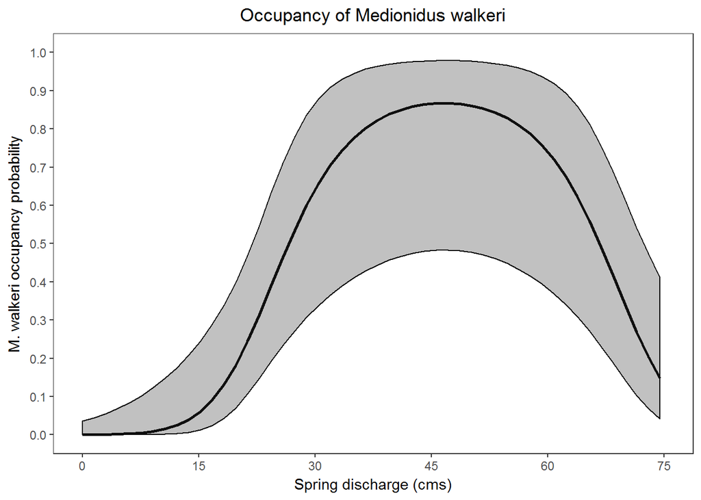

```r
(OccPlot <- ggplot(walkPredOcc, aes(x = SpringQcms, y = Predicted)) + geom_line(colour = "black", size = 1) + geom_ribbon(aes(ymin = lower, ymax = upper), alpha = 0.3, colour = "black", show.legend = F) + xlab("Spring discharge (cms)") + ylab("M. walkeri occupancy probability") + scale_x_continuous(limits = c(0, 75), breaks = c(0,15,30,45,60,75)) + scale_y_continuous(limits = c(0, 1), breaks = c(0,0.1,0.2,0.3,0.4,0.5,0.6,0.7,0.8,0.9,1.0)) + theme_bw() + theme(panel.grid.major = element_blank(), panel.grid.minor = element_blank()) + ggtitle("Occupancy of Medionidus walkeri") + theme(plot.title = element_text(hjust = 0.5)))
```

### Note that you can also save the plot that’s produced in a variety of formats using the ggsave function.

**The plot will be saved to your working directory.**

```r
ggsave("OccPlot.jpg", OccPlot, width = 4, height = 5, dpi = 600)
```

### Now we’ll make another plot, only this time for detection probability.

**To do so, however, we need to modify the stEffort and Effort data frames a little bit. First we’ll create a new data frame called walkeriObsind based on the observation (detection/non-detection) data, and within that data frame we convert all 0 observations to 1. This is because there are a lot of NAs in the observation data (i.e., occasions that never occurred), and we need to account for the NAs to properly calculate the mean and sd of effort. Note that Unmarked ignores covariate values (here, Effort and stEffort) associated with missing observations (NA). We then “melt” the Effort and stEffort data frames and calculate the mean and SD of Effort. Recall that we included stEffort as a covariate, so to make a nice plot we want to predict detection based on stEffort but plot as a function of Effort (similar to above with SpringQcms).**

```r
walkeriObsind<-walkeriObs # make new data frame
walkeriObsind[walkeriObsind == 0] <- 1 # convert "0" observations to "1".
stEffCor<-stEffort[,2:9]*walkeriObsind # multiply observations (all 1) x stEffort, which retaints the NAs, too.
EffCor<-Effort[,2:9]*walkeriObsind # multiply observations x Effort (retains NAs)
EffCor<-melt(EffCor) # Melt the EffCor data frame into long format
```

```
## Using  as id variables
```

```r
stEffCor<-melt(stEffCor) # Melt the stEffCor data frame into a long format
```

```
## Using  as id variables
```

```r
(Effmean<-mean(EffCor$value, na.rm = T)) # mean of Effort = 0.3825831
```

```
## [1] 0.3825831
```

```r
(EffSD<-sd(EffCor$value, na.rm = T))   # SD of Effort = 0.1709319
```

```
## [1] 0.1709319
```

```r
(mean(stEffCor$value, na.rm = T)) # should be 0
```

```
## [1] 0.0000000001978852
```

```r
(sd(stEffCor$value, na.rm = T)) # should be 1
```

```
## [1] 1
```

```r
(RangeStEff<-range(stEffCor$value, na.rm = T)) # -2.039310  6.537206
```

```
## [1] -2.039310  6.537206
```

```r
newdat2<-data.frame(stEffort = seq(RangeStEff[1],RangeStEff[2], length.out = 50))
newdat2$Effort<-newdat2$stEffort*EffSD + Effmean
print(newdat2[1:24,])
```

```
##       stEffort     Effort
## 1  -2.03930986 0.03400000
## 2  -1.86427892 0.06391837
## 3  -1.68924799 0.09383673
## 4  -1.51421706 0.12375510
## 5  -1.33918613 0.15367347
## 6  -1.16415520 0.18359184
## 7  -0.98912427 0.21351020
## 8  -0.81409334 0.24342857
## 9  -0.63906241 0.27334694
## 10 -0.46403147 0.30326531
## 11 -0.28900054 0.33318367
## 12 -0.11396961 0.36310204
## 13  0.06106132 0.39302041
## 14  0.23609225 0.42293878
## 15  0.41112318 0.45285714
## 16  0.58615411 0.48277551
## 17  0.76118505 0.51269388
## 18  0.93621598 0.54261224
## 19  1.11124691 0.57253061
## 20  1.28627784 0.60244898
## 21  1.46130877 0.63236735
## 22  1.63633970 0.66228571
## 23  1.81137063 0.69220408
## 24  1.98640156 0.72212245
```

### Now we’re read to make detection predictions and plot them as a function of effort.

```r
walkPredDet<-predict(walk_mod1, type = 'det', newdata = newdat2, se.fit = T, appendData=T)
print(walkPredDet)
```

```
##    Predicted         SE      lower     upper    stEffort     Effort
## 1  0.1046161 0.07566629 0.02342651 0.3626849 -2.03930986 0.03400000
## 2  0.1162839 0.07823167 0.02874284 0.3691186 -1.86427892 0.06391837
## 3  0.1290655 0.08041594 0.03518226 0.3758744 -1.68924799 0.09383673
## 4  0.1430246 0.08214837 0.04294227 0.3830132 -1.51421706 0.12375510
## 5  0.1582192 0.08336501 0.05223578 0.3906125 -1.33918613 0.15367347
## 6  0.1746990 0.08401530 0.06328191 0.3987719 -1.16415520 0.18359184
## 7  0.1925027 0.08407046 0.07629055 0.4076206 -0.98912427 0.21351020
## 8  0.2116555 0.08353390 0.09143877 0.4173266 -0.81409334 0.24342857
## 9  0.2321660 0.08245359 0.10883750 0.4281089 -0.63906241 0.27334694
## 10 0.2540236 0.08093578 0.12848847 0.4402510 -0.46403147 0.30326531
## 11 0.2771962 0.07915824 0.15023477 0.4541136 -0.28900054 0.33318367
## 12 0.3016279 0.07737905 0.17371471 0.4701381 -0.11396961 0.36310204
## 13 0.3272381 0.07593292 0.19833818 0.4888284  0.06106132 0.39302041
## 14 0.3539207 0.07520398 0.22331363 0.5106886  0.23609225 0.42293878
```

[output cut: 36 more lines]

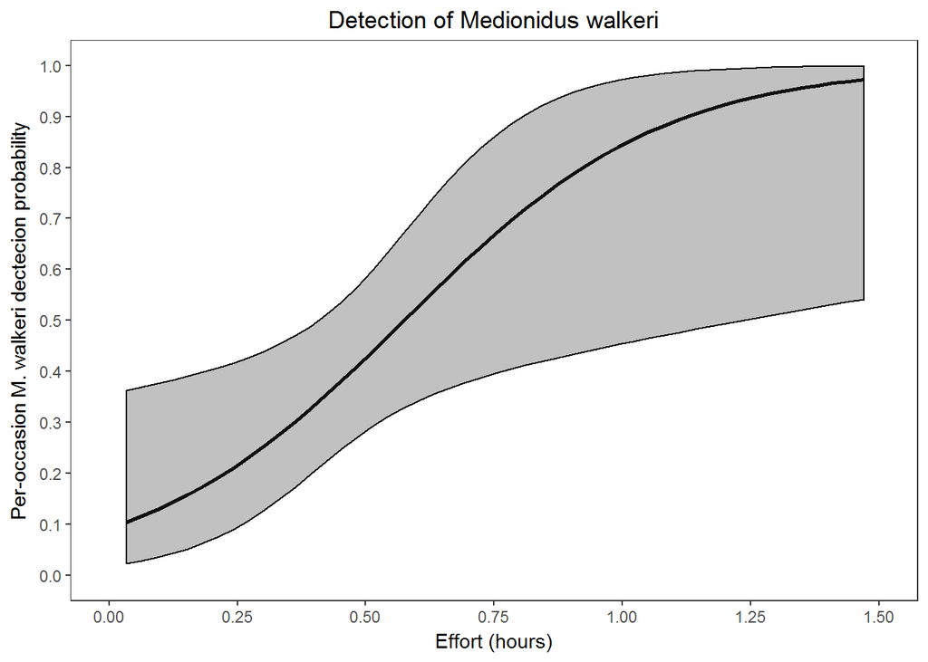

```r
(DetPlot <- ggplot(walkPredDet, aes(x = Effort, y = Predicted)) + geom_line(colour = "black", size = 1) + geom_ribbon(aes(ymin = lower, ymax = upper), alpha = 0.3, colour = "black", show.legend = F) + xlab("Effort (hours)") + ylab("Per-occasion M. walkeri dectecion probability") + scale_x_continuous(limits = c(0, 1.5), breaks = c(0,0.25, 0.50, 0.75, 1.0, 1.25, 1.5)) + scale_y_continuous(limits = c(0, 1), breaks = c(0,0.1,0.2,0.3,0.4,0.5,0.6,0.7,0.8,0.9,1.0)) + theme_bw() + theme(panel.grid.major = element_blank(), panel.grid.minor = element_blank()) +  ggtitle("Detection of Medionidus walkeri") + theme(plot.title = element_text(hjust = 0.5)))
```

### And again we can save this in any format we like using ggsave().

```r
ggsave("DetPlot.jpg", DetPlot, width = 4, height = 5, dpi = 600)
```